# Lecture 3: Geometry of OLS and partitioned regression

Economics 527: Econometric Methods

Vadim Marmer, UBC

# Geometry of OLS

## Least squares as a distance

- OLS, first lecture:
  $$\hat\beta = \underset{b \in \mathbb{R}^k}{\arg\min}\ \underbrace{(Y - Xb)^\top (Y - Xb)}_{=\, \|Y - Xb\|^2}$$
- Norm of $a \in \mathbb{R}^n$:
  $$\begin{aligned}
  \|a\| &= \sqrt{\sum_{i=1}^n a_i^2} \\
  &= \sqrt{a^\top a}
  \end{aligned}$$

## Column space $S(X)$

- Column space of $X$:
  $$S(X) = \big\{\, v \in \mathbb{R}^n : v = \underset{n\times k}{X}\, \underbrace{b}_{k\times 1} \ \text{ for some } b \in \mathbb{R}^k \,\big\}$$
- Partition $X$ column-wise:
  $$\underbrace{X}_{n\times k} = \big[\, \underbrace{\underline{X}_1}_{n\times 1} \ \cdots \ \underbrace{\underline{X}_k}_{n\times 1} \,\big],$$
  where $\underline{X}_j$ is the $n \times 1$ vector of the observations on the $j$-th regressor.
- What the elements of $S(X)$ look like, in terms of the columns of $X$:
  $$\begin{aligned}
  \underbrace{X}_{n\times k}\underbrace{b}_{k\times 1} &= \underbrace{\big[\, \underline{X}_1 \ \cdots \ \underline{X}_k \,\big]}_{=X} \begin{bmatrix} b_1 \\ \vdots \\ b_k \end{bmatrix} \\
  &= b_1 \underline{X}_1 + \cdots + b_k \underline{X}_k \\
  &= \sum_{j=1}^{k} b_j \underline{X}_j
  \end{aligned}$$
- Each $\underline{X}_j \in S(X)$, since we can take $b_j = 1$, $b_i = 0$ for $i \ne j$:
  $$\begin{aligned}
  Xb &= \big[\, \underline{X}_1 \ \cdots \ \underline{X}_k \,\big] \begin{bmatrix} 0 \\ \vdots \\ 1 \\ \vdots \\ 0 \end{bmatrix} \\
  &= \underline{X}_j \in S(X)
  \end{aligned}$$
- $S(X) \subset \mathbb{R}^n$: $k$-dimensional subspace; $\operatorname{rank}\left(X\right) = k < n$.

## $\hat Y$: closest to $Y$ in $S(X)$

- We can re-state the OLS problem in terms of $S(X)$:
  $$\begin{aligned}
  & \hat\beta = \underset{b \in \mathbb{R}^k}{\arg\min}\ \|Y - Xb\|^2, \qquad \hat Y = X\hat\beta \\
  & \Longleftrightarrow \\
  \hat Y &= \underset{v \in S(X)}{\arg\min}\ \|Y - v\|^2
  \end{aligned}$$
- When $k = 1$, $n = 2$, we can visualize the solution: You can find the closest element by dropping a perpendicular from $Y$ to $S(X)$.
- $Y = (Y_1, Y_2)^\top$, $X = (X_1, X_2)^\top$, and $S(X)=\{(bX_1, bX_2)^\top : b \in \mathbb{R}\}$.

[figure not shown]

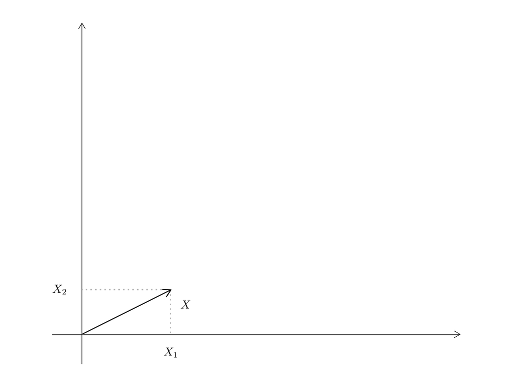

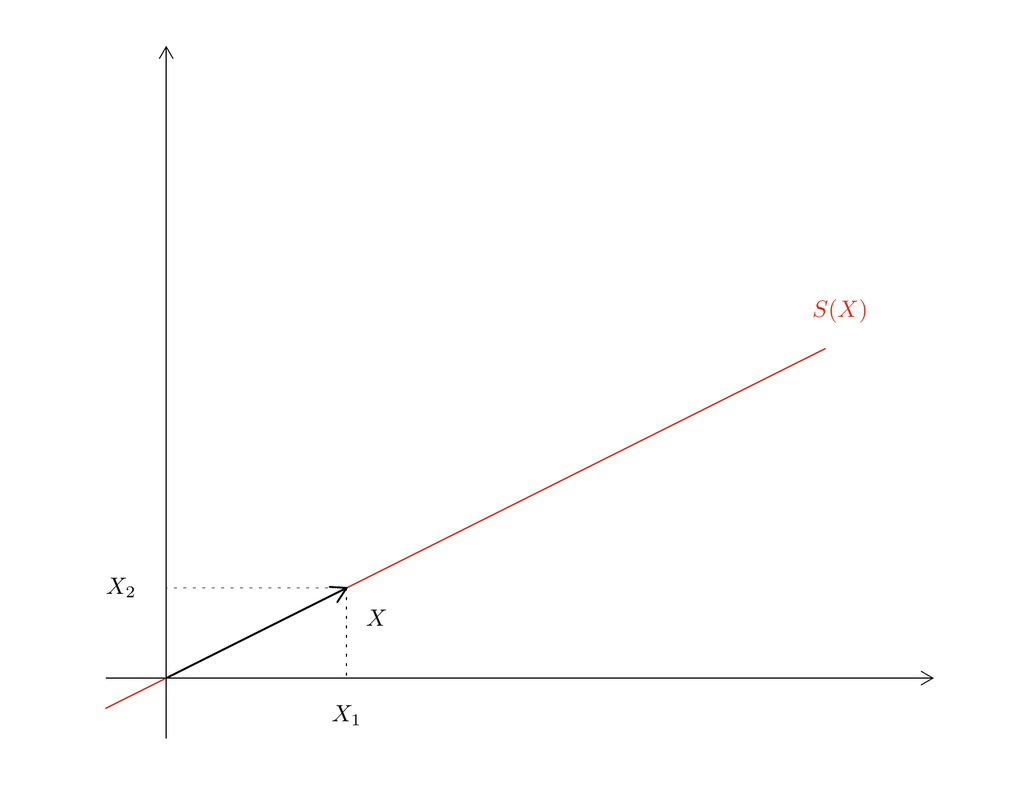

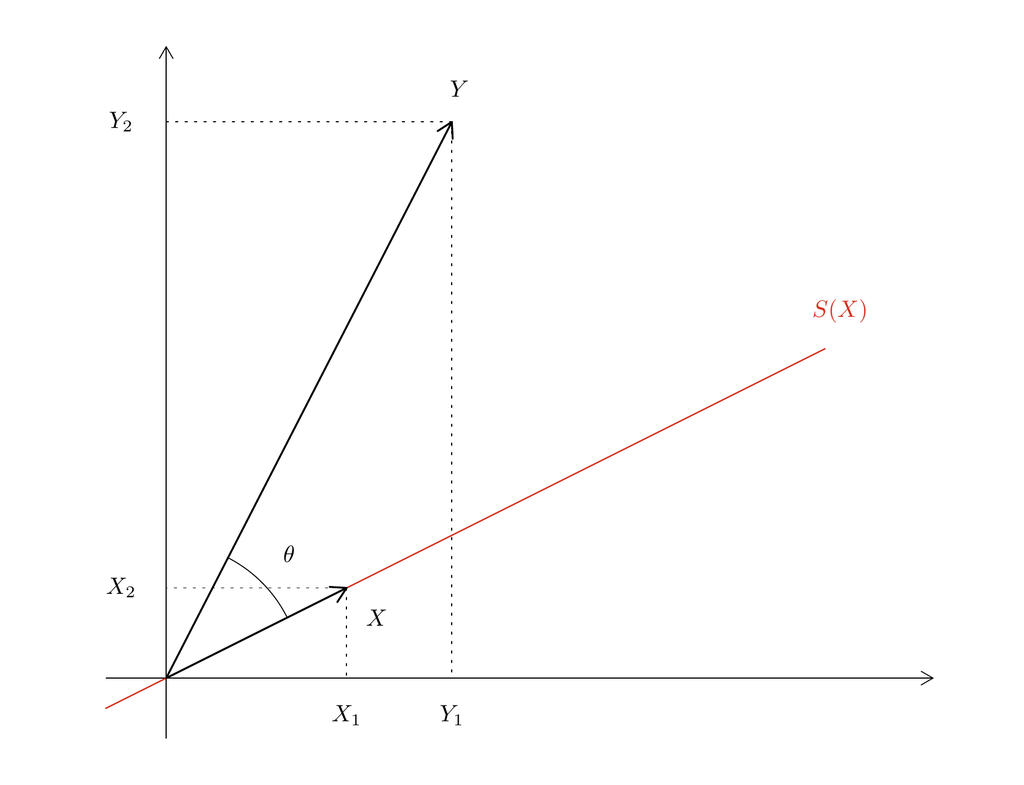

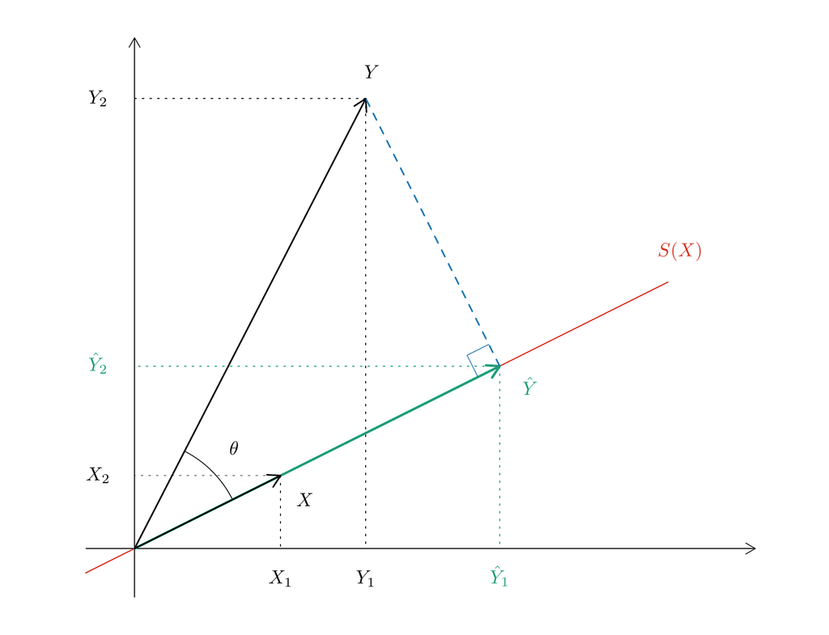

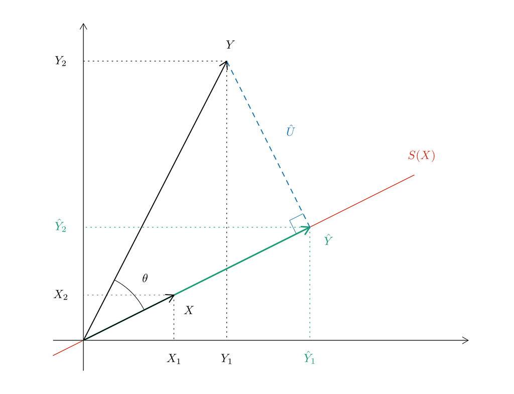

- The coefficient $\hat\beta$ is determined by the angle $\theta$ between $X$ and $Y$:
  $$\begin{aligned}
  \cos\theta &= \frac{X^\top Y}{\|X\|\,\|Y\|} \\
  \hat\beta &= \frac{X^\top Y}{\|X\|^2} \\
  &= \cos\theta \cdot \frac{\|Y\|}{\|X\|}
  \end{aligned}$$
- Residuals, perpendicular to $S(X)$:
  $$\begin{aligned}
  \hat U &= Y - \hat Y = Y - X\hat\beta
  \end{aligned}$$

## Dropping the perpendicular: the algebra

- Fitted values:
  $$\begin{aligned}
  \hat Y &= X\hat\beta \\
  &= \underbrace{X (X^\top X)^{-1} X^\top}_{P_X}\, Y \\
  &= P_X Y
  \end{aligned}$$
- Residuals:
  $$\begin{aligned}
  \hat U &= Y - \hat Y \\
  &= Y - P_X Y \\
  &= \underbrace{(I_n - P_X)}_{=\, M_X}\, Y \\
  &= M_X Y
  \end{aligned}$$
- Both $n \times n$:
  $$\boxed{\ P_X = \underset{n\times k}{X}\ \underset{k\times k}{(X^\top X)}^{-1} \underset{k\times n}{X}^\top \qquad M_X = \underset{n\times n}{I_n} - \underset{n\times n}{P_X}\ }$$

# Projection matrices

## $P_X Y$ and $M_X Y$

- Decomposition of $Y \in \mathbb{R}^n$:
  $$\begin{aligned}
  P_X + M_X &= I_n \\
  \Longrightarrow\quad P_X Y + M_X Y &= Y
  \end{aligned}$$

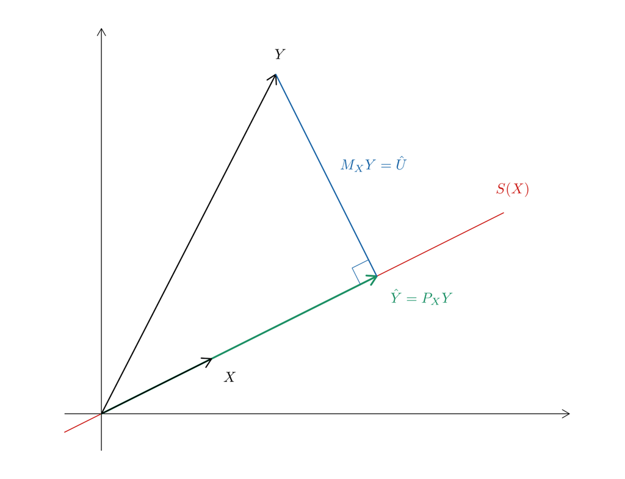

## Properties of $P_X$

- Symmetric, by $(AB)^\top = B^\top A^\top$:
  $$\begin{aligned}
  P_X^\top &= \big( X (X^\top X)^{-1} X^\top \big)^\top \\
  &= X (X^\top X)^{-1} X^\top \\
  &= P_X
  \end{aligned}$$
- $P_X X = X$:
  $$\begin{aligned}
  P_X X &= \underbrace{X (X^\top X)^{-1} X^\top}_{P_X}\, X \\
  &= X
  \end{aligned}$$
- Column by column, $P_X \underline{X}_j = \underline{X}_j$ for $j = 1, \ldots, k$:
  $$\begin{aligned}
  P_X X &= P_X \big[\, \underset{n\times 1}{\underline{X}_1} \ \cdots \ \underset{n\times 1}{\underline{X}_k} \,\big] \\
  &= \big[\, P_X \underline{X}_1 \ \cdots \ P_X \underline{X}_k \,\big] \\
  &= \big[\, \underline{X}_1 \ \cdots \ \underline{X}_k \,\big],
  \end{aligned}$$
  where the last equality holds because $P_X X=X$.
- Idempotent:
  $$\begin{aligned}
  P_X^2 &= P_X P_X \\
  &= \underbrace{P_X X}_{=\, X}\, (X^\top X)^{-1} X^\top \\
  &= P_X
  \end{aligned}$$

## $P_X$: p.s.d., trace $k$

- For $a \in \mathbb{R}^n$:
  $$\begin{aligned}
  a^\top P_X a &= \underbrace{a^\top X}_{w^\top}\ \underbrace{(X^\top X)^{-1}}_{\text{p.d.}}\ \underbrace{X^\top a}_{w} \\
  &\ge 0
  \end{aligned}$$
- We will use: $\operatorname{tr}(AB) = \operatorname{tr}(BA)$.
  $$\begin{aligned}
  \operatorname{tr}(P_X) &= \operatorname{tr}\big( X (X^\top X)^{-1} X^\top \big) \\
  &= \operatorname{tr}\big( (X^\top X)^{-1} \underbrace{\underset{k\times n}{X^\top}\, \underset{n\times k}{X}}_{k\times k} \big) \\
  &= \operatorname{tr}(I_k) \\
  &= k
  \end{aligned}$$
- $P_X$: $n \times n$, symmetric, p.s.d., idempotent, rank $k$.
- $P_X: \mathbb{R}^n \longrightarrow S(X)$.

## Properties of $M_X$

- Symmetric:
  $$\begin{aligned}
  M_X^\top &= I_n^\top - P_X^\top \\
  &= I_n - P_X \\
  &= M_X
  \end{aligned}$$
- $M_X X = 0$:
  $$\begin{aligned}
  M_X X &= (I_n - P_X) X \\
  &= X - \underbrace{P_X X}_{=\, X} \\
  &= X - X \\
  &= 0
  \end{aligned}$$
- $v = Xb \in S(X)$, $b \in \mathbb{R}^k$:
  $$\begin{aligned}
  M_X v &= M_X X b \\
  &= 0
  \end{aligned}$$

## $M_X P_X = 0$ and idempotency

- $M_X P_X = 0$ and $P_X M_X = 0$:
  $$\begin{aligned}
  M_X P_X &= \underbrace{M_X X}_{=\, 0}\, (X^\top X)^{-1} X^\top \\
  &= 0 \\
  P_X M_X &= (M_X P_X)^\top \\
  &= 0
  \end{aligned}$$
- Idempotent:
  $$\begin{aligned}
  M_X M_X &= (I_n - P_X) M_X \\
  &= M_X - \underbrace{P_X M_X}_{=\, 0} \\
  &= M_X
  \end{aligned}$$

## Orthogonal complement $S^\perp(X)$

- Orthogonal complement of $S(X)$:
  $$S^\perp(X) = \big\{\, v \in \mathbb{R}^n : v^\top X = 0 \,\big\}$$
- Normal equations, first lecture:
  $$\begin{aligned}
  X^\top \hat U &= X^\top (Y - X\hat\beta) \\
  &= X^\top Y - X^\top X \underbrace{\hat\beta}_{=\, (X^\top X)^{-1} X^\top Y} \\
  &= X^\top Y - X^\top Y \\
  &= 0 \\
  \Longrightarrow\quad \hat U^\top X &= 0 \\
  \Longrightarrow\quad \hat U &= M_X Y \in S^\perp(X)
  \end{aligned}$$
- $M_X: \mathbb{R}^n \longrightarrow S^\perp(X)$.

## $M_X$: rank $n - k$, p.s.d.

- Rank:
  $$\begin{aligned}
  \operatorname{rank}\left(M_X\right) &= \operatorname{tr}(M_X) \\
  &= \operatorname{tr}(I_n - P_X) \\
  &= \operatorname{tr}(I_n) - \operatorname{tr}(P_X) \\
  &= n - k
  \end{aligned}$$
- $M_X$: $n \times n$; no inverse.
- **Claim.** $M_X$: p.s.d. For $a \in \mathbb{R}^n$ and $w = M_X a$:
  $$\begin{aligned}
  a^\top M_X a &= a^\top M_X M_X a \quad \text{(idempotent)} \\
  &= \underbrace{a^\top M_X^\top}_{w^\top}\ \underbrace{M_X a}_{w} \quad \text{(symmetric)} \\
  &= w^\top w \\
  &= \|w\|^2 \\
  &\ge 0
  \end{aligned}$$

## $Y = \hat Y + \hat U$

- Decomposition:
  $$\underset{\in\, \mathbb{R}^n}{Y} = \underset{\in\, S(X)}{\hat Y} + \underset{\in\, S^\perp(X)}{\hat U}, \qquad S(X) + S^\perp(X) = \mathbb{R}^n$$
- Fitted values:
  $$\begin{aligned}
  \hat Y &= X\hat\beta \\
  &= P_X Y \in S(X), \quad \text{dimension } k
  \end{aligned}$$
- Residuals:
  $$\begin{aligned}
  \hat U &= Y - \hat Y \\
  &= M_X Y \in S^\perp(X), \quad \text{dimension } n - k
  \end{aligned}$$
- Orthogonality:
  $$\begin{aligned}
  \hat Y^\top \hat U &= Y^\top P_X^\top M_X Y \\
  &= Y^\top \underbrace{P_X M_X}_{=\, 0}\, Y \\
  &= 0
  \end{aligned}$$

# Estimation of $\sigma^2$

## Two estimators of $\sigma^2$

- Assumptions 2 and 3:
  $$\begin{aligned}
  \mathrm{Var}\left(U \mid X\right) &= \mathrm{E}\left[U U^\top \mid X\right] \\
  &= \sigma^2 I_n
  \end{aligned}$$
- Unknown parameter:
  $$\begin{aligned}
  \sigma^2 &= \mathrm{E}\left[U_i^2 \mid X\right] \\
  &= \mathrm{E}\left[U_i^2\right]
  \end{aligned}$$
- Estimators:
  $$\begin{aligned}
  \hat\sigma^2 &= \frac{1}{n} \sum_{i=1}^n \hat U_i^2 \\
  &= \frac{1}{n} \sum_{i=1}^n (Y_i - X_i^\top \underset{k\times 1}{\hat\beta})^2 \\
  &= \frac{1}{n}\, \hat U^\top \hat U \\
  s^2 &= \frac{1}{n-k} \sum_{i=1}^n \hat U_i^2
  \end{aligned}$$
- **Claim.** Under Assumptions 1 to 4:
  $$\mathrm{E}\left[s^2 \mid X\right] = \sigma^2$$

## Proof, step 1: residuals to errors

- Residuals:
  $$\begin{aligned}
  \hat U &= M_X Y \\
  &= M_X (X\beta + U) \quad \text{(Assumption 1)} \\
  &= M_X U \quad (M_X X = 0)
  \end{aligned}$$
- Dimensions:
  $$\underset{n\times 1}{\hat U} = \underset{n\times n}{M_X}\ \underset{n\times 1}{U}, \qquad \operatorname{rank}\left(M_X\right) = n - k$$
- Sum of squared residuals:
  $$\begin{aligned}
  \sum_{i=1}^n \hat U_i^2 &= \|\hat U\|^2 \\
  &= \hat U^\top \hat U \\
  &= (M_X U)^\top (M_X U) \\
  &= U^\top M_X^\top M_X U \\
  &= U^\top M_X U \quad \text{(symmetric, idempotent)}
  \end{aligned}$$

- The quadratic form $U^\top M_X U$ is a scalar:
  $$\overbrace{\underset{1\times n}{U^\top}\ \underset{n\times n}{M_X}\ \underset{n\times 1}{U}}^{1\times 1}$$
- Treat any scalar $c$ as a $1 \times 1$ matrix:
  $$\begin{aligned}
  c &= \operatorname{tr}(c).
  \end{aligned}$$
- We have:
  $$\begin{aligned}
  \mathrm{E}\left[\hat U^\top \hat U \mid X\right] &= \mathrm{E}\left[U^\top M_X U \mid X\right] \\
  &= \mathrm{E}\left[\operatorname{tr}\big({\color{red} U^\top} M_X U\big) \mid X\right] \quad \text{(scalar $=$ its trace)} \\
  &= \mathrm{E}\left[\operatorname{tr}\big(M_X U {\color{red} U^\top}\big) \mid X\right] \quad \text{($\operatorname{tr}(AB) = \operatorname{tr}(BA)$)} \\
  &= \operatorname{tr}\big(\mathrm{E}\left[M_X U U^\top \mid X\right]\big) \\
  &= \operatorname{tr}\big(M_X \underbrace{\mathrm{E}\left[U U^\top \mid X\right]}_{=\, \sigma^2 I_n}\big) \\
  &= \sigma^2 \operatorname{tr}(M_X) \\
  &= \sigma^2 (n - k)
  \end{aligned}$$

## $\hat\sigma^2$: biased

- Residuals:
  $$\begin{aligned}
  \mathrm{E}\left[\sum_{i=1}^n \hat U_i^2 \mid X\right] &= \sigma^2 (n - k) \\
  \Longrightarrow\quad \mathrm{E}\left[\sum_{i=1}^n \hat U_i^2\right] &= \sigma^2 (n - k) \quad \text{(LIE)}
  \end{aligned}$$
- Errors:
  $$\begin{aligned}
  \mathrm{E}\left[U^\top U\right] &= \mathrm{E}\left[\sum_{i=1}^n U_i^2\right] \\
  &= n \sigma^2
  \end{aligned}$$
- Biased, by a known factor:
  $$\begin{aligned}
  \mathrm{E}\left[\hat\sigma^2 \mid X\right] &= \frac{1}{n}\, \mathrm{E}\left[\hat U^\top \hat U \mid X\right] \\
  &= \frac{n-k}{n}\, \sigma^2 \\
  &\ne \sigma^2
  \end{aligned}$$

## $s^2$: unbiased

- Correction:
  $$\begin{aligned}
  \frac{n}{n-k}\, \mathrm{E}\left[\hat\sigma^2 \mid X\right] &= \sigma^2 \\
  s^2 &= \frac{n}{n-k}\, \hat\sigma^2 \\
  &= \frac{\hat U^\top \hat U}{n-k} \\
  &= \frac{\sum_{i=1}^n \hat U_i^2}{n-k} \\
  &= \frac{\sum_{i=1}^n (Y_i - X_i^\top \hat\beta)^2}{n-k} \\
  &= \frac{\|Y - X\hat\beta\|^2}{n-k}
  \end{aligned}$$
- Unbiased:
  $$\begin{aligned}
  & \boxed{\ \mathrm{E}\left[s^2 \mid X\right] = \sigma^2\ } \\
  \overset{\text{LIE}}{\Longrightarrow}\quad & \mathrm{E}\left[s^2\right] = \sigma^2
  \end{aligned}$$

## Standard errors

- Second lecture: $\mathrm{Var}\left(\hat\beta \mid X\right) = \sigma^2 (X^\top X)^{-1}$. Estimated:
  $$\widehat{\mathrm{Var}}\big(\hat\beta \mid X\big) = s^2 (X^\top X)^{-1}$$
- Standard error against standard deviation:
  $$\begin{aligned}
  \text{std. err}\big(\hat\beta_j\big) &= \sqrt{s^2 \big[(X^\top X)^{-1}\big]_{jj}} \\
  &= \sqrt{\widehat{\mathrm{Var}}\big(\hat\beta_j \mid X\big)} \\
  \text{std. dev}\big(\hat\beta_j\big) &= \sqrt{\mathrm{Var}\left(\hat\beta_j \mid X\right)}
  \end{aligned}$$

# Partitioned regression

## Partition

- Two blocks of regressors, $k_1 + k_2 = k$:
  $$\underset{n\times k}{X} = \big[\ \underset{n\times k_1}{X_1} \quad \underset{n\times k_2}{X_2}\ \big], \qquad
  \beta = \begin{bmatrix} \beta_1 \\ \beta_2 \end{bmatrix}
  \begin{matrix} k_1 \times 1 \\ k_2 \times 1 \end{matrix}$$
- The model can be written as
  $$\begin{aligned}
  Y &= \big[\ X_1 \quad X_2\ \big] \begin{bmatrix} \beta_1 \\ \beta_2 \end{bmatrix} + U \\
  &= X_1 \beta_1 + X_2 \beta_2 + U
  \end{aligned}$$
- OLS:
  $$\begin{aligned}
  \underset{k\times 1}{\hat\beta} &= \begin{bmatrix} \underset{k_1\times 1}{\hat\beta_1} \\ \underset{k_2\times 1}{\hat\beta_2} \end{bmatrix} \\
  &= (X^\top X)^{-1} X^\top Y
  \end{aligned}$$

## Frisch-Waugh-Lovell (FWL) theorem

- **Claim.**
  $$\hat\beta_1 = (X_1^\top M_2 X_1)^{-1} X_1^\top M_2 Y, \qquad M_2 = I_n - P_2, \quad P_2 = X_2 (X_2^\top X_2)^{-1} X_2^\top$$
- $M_2$: symmetric, idempotent, $M_2 X_2 = 0$.
- Similarly:
  $$\hat\beta_2 = (X_2^\top M_1 X_2)^{-1} X_2^\top M_1 Y, \quad M_1 = I_n - X_1 (X_1^\top X_1)^{-1} X_1^\top.$$

## Proof

- We will use:
  $$\begin{aligned}
  \hat U &= Y - X\hat\beta \\
  &= Y - X_1 \hat\beta_1 - X_2 \hat\beta_2 \\
  \Longleftrightarrow\quad Y &= X\hat\beta + \hat U \\
  &= X_1 \hat\beta_1 + X_2 \hat\beta_2 + \hat U
  \end{aligned}$$
- We have:
  $$\begin{aligned}
  & (X_1^\top M_2 X_1)^{-1} X_1^\top M_2 Y \\
  &= (X_1^\top M_2 X_1)^{-1} X_1^\top M_2 \big( X_1 \hat\beta_1 + X_2 \hat\beta_2 + \hat U \big) \\
  &= \underbrace{(X_1^\top M_2 X_1)^{-1} X_1^\top M_2 X_1}_{=\, I_{k_1}}\, \hat\beta_1 \\
  &\qquad + (X_1^\top M_2 X_1)^{-1} X_1^\top {\color{red} \underbrace{M_2 X_2}_{=\, 0}}\, \hat\beta_2 \\
  &\qquad + (X_1^\top M_2 X_1)^{-1} X_1^\top M_2 \hat U \\
  &= \hat\beta_1 + (X_1^\top M_2 X_1)^{-1} X_1^\top \underbrace{M_2 \hat U}_{=\, \hat U} \\
  &= \hat\beta_1 + (X_1^\top M_2 X_1)^{-1} {\color{red} \underbrace{X_1^\top \hat U}_{=\, 0}} \\
  &= \boxed{\hat\beta_1}
  \end{aligned}$$

## $M_2 \hat U = \hat U$

- Normal equations, block by block:
  $$\begin{aligned}
  0 &= X^\top \hat U \\
  &= \big[\ X_1 \quad X_2\ \big]^\top \hat U \\
  &= \begin{bmatrix} X_1^\top \\ X_2^\top \end{bmatrix} \hat U \\
  &= \begin{bmatrix} X_1^\top \hat U \\ X_2^\top \hat U \end{bmatrix} \\
  &= \begin{bmatrix} 0 \\ 0 \end{bmatrix}
  \end{aligned}$$
- Hence:
  $$\begin{aligned}
  M_2 \hat U &= (I_n - P_2) \hat U \\
  &= \hat U - P_2 \hat U \\
  &= \hat U - X_2 (X_2^\top X_2)^{-1} \underbrace{X_2^\top \hat U}_{=\, 0} \\
  &= \hat U
  \end{aligned}$$
- Hence:
  $$\begin{aligned}
  X_1^\top M_2 \hat U &= X_1^\top \hat U \\
  &= 0
  \end{aligned}$$

## Residuals on residuals

- We will use: $M_2^\top = M_2$ and $M_2 M_2 = M_2$.
- We have:
  $$\begin{aligned}
  \hat\beta_1 &= (X_1^\top M_2 X_1)^{-1} X_1^\top M_2 Y \\
  &= (X_1^\top M_2^\top M_2 X_1)^{-1} X_1^\top M_2^\top M_2 Y \\
  &= \big( (M_2 X_1)^\top (M_2 X_1) \big)^{-1} (M_2 X_1)^\top (M_2 Y) \\
  &= (\tilde X_1^\top \tilde X_1)^{-1} \tilde X_1^\top \tilde Y
  \end{aligned}$$
- $\tilde X_1 = M_2 X_1$, $\tilde Y = M_2 Y$, $\tilde U = M_2 U$:
  $$\begin{aligned}
  Y &= X_1 \beta_1 + X_2 \beta_2 + U \\
  M_2 Y &= M_2 X_1 \beta_1 + \underbrace{M_2 X_2}_{=\, 0}\, \beta_2 + M_2 U \\
  &= M_2 X_1 \beta_1 + M_2 U \\
  \tilde Y &= \tilde X_1 \beta_1 + \tilde U
  \end{aligned}$$

## $\tilde X_1$ and $\tilde Y$: OLS residuals

- Residuals from the regression of the columns of $X_1$ against $X_2$:
  $$\begin{aligned}
  \tilde X_1 &= M_2 X_1 \\
  &= (I_n - P_2) X_1 \\
  &= X_1 - P_2 X_1 \\
  &= X_1 - X_2 \underbrace{(X_2^\top X_2)^{-1} X_2^\top X_1}_{\hat\gamma} \\
  &= X_1 - X_2 \hat\gamma \\
  \Longleftrightarrow\quad X_1 &= X_2 \hat\gamma + \tilde X_1
  \end{aligned}$$
- $\tilde X_1^\top X_2 = 0$.
- Residuals from the regression of $Y$ against $X_2$:
  $$\begin{aligned}
  \tilde Y &= M_2 Y \\
  &= Y - X_2 \underbrace{(X_2^\top X_2)^{-1} X_2^\top Y}_{\hat\eta} \\
  \Longleftrightarrow\quad Y &= X_2 \hat\eta + \tilde Y
  \end{aligned}$$

## Regression in three steps

1. Remove from $X_1$ the part collinear with $X_2$: $\tilde X_1$.
2. Remove from $Y$ the part collinear with $X_2$: $\tilde Y$.
3. $\hat\beta_1$: the OLS coefficient from the regression of $\tilde Y$ against $\tilde X_1$.
- $\hat\beta_1$: the estimated effect of $X_1$ after controlling for $X_2$.
- Step 2 optional:
  $$\begin{aligned}
  \hat\beta_1 &= (X_1^\top M_2 X_1)^{-1} X_1^\top M_2 Y \\
  &= (X_1^\top M_2^\top M_2 X_1)^{-1} X_1^\top M_2^\top Y \\
  &= \big( (M_2 X_1)^\top (M_2 X_1) \big)^{-1} (M_2 X_1)^\top Y \\
  &= (\tilde X_1^\top \tilde X_1)^{-1} \tilde X_1^\top Y
  \end{aligned}$$
- Step 1 is not optional:
  $$(X_1^\top X_1)^{-1} X_1^\top \tilde Y = (X_1^\top X_1)^{-1} X_1^\top M_2 Y \ \ne\ ( X_1^\top M_2 X_1)^{-1} X_1^\top M_2 Y \quad \text{in general}$$

# Partitioned regression and the intercept

## Intercept as a regressor

- One regressor and an intercept:
  $$Y_i = \underset{1\times 1}{\beta_1} + \underset{1\times 1}{\beta_2}\, \underset{1\times 1}{X_{i,2}} + U_i$$
- Matrix form, with $\ell$ the $n \times 1$ vector of ones:
  $$\begin{aligned}
  X &= \begin{bmatrix} 1 & X_{1,2} \\ \vdots & \vdots \\ 1 & X_{n,2} \end{bmatrix} \\
  &= \big[\ \ell \quad X_2\ \big] \\
  Y &= \underset{1\times 1}{\beta_1}\, \underset{n\times 1}{\ell} + \underset{1\times 1}{\beta_2}\, \underset{n\times 1}{X_2} + U
  \end{aligned}$$
- Partitioned regression:
  $$\begin{aligned}
  \underset{1\times 1}{\hat\beta_2} &= \big( \underset{1\times 1}{X_2^\top M_\ell X_2} \big)^{-1}\, \underset{1\times n}{X_2^\top}\ \underset{n\times 1}{M_\ell Y} = \frac{X_2^\top M_\ell Y}{X_2^\top M_\ell X_2} \\
  M_\ell &= I_n - \ell \big( \underset{1\times 1}{\ell^\top \ell} \big)^{-1} \ell^\top
  \end{aligned}$$

## $P_\ell$ and $M_\ell$

- $\ell^\top \ell$:
  $$\begin{aligned}
  \ell^\top \ell &= \begin{bmatrix} 1 \\ \vdots \\ 1 \end{bmatrix}^\top \begin{bmatrix} 1 \\ \vdots \\ 1 \end{bmatrix} \\
  &= \sum_{i=1}^n 1 \cdot 1 \\
  &= n
  \end{aligned}$$
- Hence:
  $$\begin{aligned}
  P_\ell &= \ell (\ell^\top \ell)^{-1} \ell^\top \\
  &= \frac{\ell \ell^\top}{n} \\
  M_\ell &= I_n - \frac{\ell \ell^\top}{n}
  \end{aligned}$$
- For $v = (v_1, \ldots, v_n)^\top$:
  $$\begin{aligned}
  (\ell^\top \ell)^{-1} \ell^\top v &= \frac{\ell^\top v}{n} \\
  &= \frac{\sum_{i=1}^n \ell_i v_i}{n} \\
  &= \frac{\sum_{i=1}^n v_i}{n} \\
  &= \bar v
  \end{aligned}$$
- $P_\ell v$:
  $$\begin{aligned}
  P_\ell v &= \frac{\ell \ell^\top}{n}\, v \\
  &= \ell\, \bar v \\
  &= \begin{pmatrix} \bar v \\ \vdots \\ \bar v \end{pmatrix}
  \end{aligned}$$
- $M_\ell v$:
  $$\begin{aligned}
  M_\ell v &= v - P_\ell v \\
  &= v - \ell\, \bar v \\
  &= \begin{pmatrix} v_1 - \bar v \\ \vdots \\ v_n - \bar v \end{pmatrix}
  \end{aligned}$$

## Slope estimator and deviations from the average

- We have:
  $$\begin{aligned}
  \hat\beta_2
  &= \frac{X_2^\top M_\ell Y}{X_2^\top M_\ell X_2} \\
  &= \frac{(M_\ell X_2)^\top Y}{(M_\ell X_2)^\top (M_\ell X_2)} \\
  &= \frac{(X_2 - \bar X_2\, \ell)^\top Y}{(X_2 - \bar X_2\, \ell)^\top (X_2 - \bar X_2\, \ell)} \\
  &= \frac{\sum_{i=1}^n (X_{i,2} - \bar X_2)\, Y_i}{\sum_{i=1}^n (X_{i,2} - \bar X_2)^2}.
  \end{aligned}$$

## Several regressors and an intercept

- Intercept $\beta_1$ and slope coefficients $\beta_2$:
  $$\underset{n\times k}{X} = \big[\ \underset{n\times 1}{\ell} \quad \underset{n\times (k-1)}{Z}\ \big], \qquad
  \beta = \begin{pmatrix} \beta_1 \\ \beta_2 \end{pmatrix}, \qquad
  Y = \beta_1 \ell + Z \beta_2 + U$$
- Each regressor minus its mean:
  $$\begin{aligned}
  \tilde Z &= M_\ell Z \\
  &= M_\ell \big[\, \underline{Z}_1 \ \cdots \ \underline{Z}_{k-1} \,\big] \\
  &= \big[\, M_\ell \underline{Z}_1 \ \cdots \ M_\ell \underline{Z}_{k-1} \,\big] \\
  &= \big[\, \underline{\tilde Z}_1 \ \cdots \ \underline{\tilde Z}_{k-1} \,\big]
  \end{aligned}$$
- Slope coefficients:
  $$\begin{aligned}
  \hat\beta_2 &= (Z^\top M_\ell Z)^{-1} Z^\top M_\ell Y \\
  &= (\tilde Z^\top \tilde Z)^{-1} \tilde Z^\top Y
  \end{aligned}$$
- Variation of $Z$ in the sample, with $Z_{i}$ now $(k-1) \times 1$ and $\bar Z = \frac{1}{n} \sum_{i=1}^n Z_{i}$:
  $$\begin{aligned}
  \tilde Z^\top \tilde Z &= \sum_{i=1}^n \tilde Z_{i} \tilde Z_{i}^\top \\
  &= \sum_{i=1}^n (Z_{i} - \bar Z)(Z_{i} - \bar Z)^\top
  \end{aligned}$$

# Summary

## Projections

- $P_X = X (X^\top X)^{-1} X^\top$ and $M_X = I_n - P_X$: symmetric, idempotent, p.s.d.
- $P_X X = X$, $M_X X = 0$, $P_X M_X = 0$.
- $\operatorname{tr}(P_X) = k$ and $\operatorname{rank}\left(M_X\right) = \operatorname{tr}(M_X) = n - k$.
- $Y = \hat Y + \hat U$ with $\hat Y = P_X Y \in S(X)$, $\hat U = M_X Y \in S^\perp(X)$, $\hat Y^\top \hat U = 0$.

## $s^2$ and partitioned regression

- $\hat U = M_X U$, $\hat U^\top \hat U = U^\top M_X U$, $\mathrm{E}\left[\hat U^\top \hat U \mid X\right] = \sigma^2 \operatorname{tr}(M_X) = \sigma^2 (n - k)$.
- $\mathrm{E}\left[\hat\sigma^2 \mid X\right] = \frac{n-k}{n}\, \sigma^2$; $s^2 = \hat U^\top \hat U / (n - k)$ with $\mathrm{E}\left[s^2 \mid X\right] = \sigma^2$; $\widehat{\mathrm{Var}}\big(\hat\beta \mid X\big) = s^2 (X^\top X)^{-1}$.
- Frisch-Waugh-Lovell: $\hat\beta_1 = (X_1^\top M_2 X_1)^{-1} X_1^\top M_2 Y = (\tilde X_1^\top \tilde X_1)^{-1} \tilde X_1^\top \tilde Y$, with $\tilde X_1 = M_2 X_1$ and $\tilde Y = M_2 Y$.